# Research bootcamp: opioid relapse

Duke University, Summer 2021

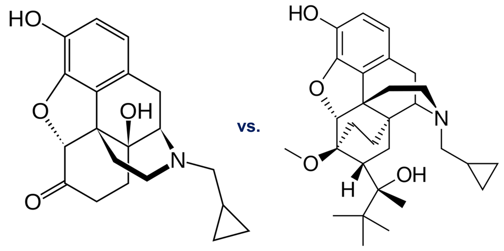

# Introduction

Since the 1990s, opioids have become an increasingly common method of pain management in Americans. However, the illicit misuse of opioids has led to a public health crisis known colloquially as the “opioid epidemic.” In 2017, almost 50,000 Americans died from an opioid overdose [1] and 1.7 million suffered from substance use disorders related to prescription opioids [2], contributing to an estimated total economic burden of $78.5 billion a year [3].

Although drug rehabilitation programs are available to combat the physical and psychological dependency on opioid medications, patients often relapse even after successful therapy. Lee and Rotrosen et al. conducted a study to compare the effectiveness of two drug therapies intended to prevent opioid relapse during drug rehabilitation [4]. This case study is based on their study data, which was sponsored by the National Institute on Drug Abuse (NIDA).

# Project objectives

Your goal is to provide a convincing statistical analysis comparing two treatments in the prevention of opioid-relapse after drug rehabilitation: extended-release naltrexone (XR-NTX) and buprenorphine-naloxone (BUP-NX). What is the difference, if any, between these two treatments in comparing the following factors:

- …time-to-relapse after receipt of therapy,
- …safety profile of the two treatments vis-a-vis adverse events?

# References

[1] Scholl L, Seth P, Kariisa M, Wilson N, Baldwin G. “Drug and opioid-involved overdose deaths - United States, 2013-2017.” MMWR. Morbidity and Mortality Weekly Report. 67 (5152): 1419–1427.

[2] Center for Behavioral Health Statistics and Quality (CBHSQ). 2017 National Survey on Drug Use and Health: Detailed Tables. Rockville, MD: Substance Abuse and Mental Health Services Administration; 2018.

[3] Florence CS, Zhou C, Luo F, Xu L. “The economic burden of prescription opioid overdose, abuse, and dependence in the United States, 2013.” Med Care. 2016; 54(10):901-906.

[4] Lee JD, Nunes EV Jr., Kovo P, et al. “Comparative effectiveness of extended- release naltrexone versus buprenorphine-naloxone for opioid relapse prevention (X:BOT): a multicentre, open-label, randomised controlled trial.” Lancet. 2018 January 27; 391(10118): 309–318.

[5] Jones CM, Campopiano M, Baldwin G, McCance-Katz E. “National and state treatment need and capacity for opioid agonist medication-assisted treatment.” Am J Public Health. 2015; 105:e55–63.

[6] The Digitalis Investigation Group. “The effect of digoxin on mortality and morbidity in patients with heart failure.” N Engl J Med 1997; 336:525-533.